# Task 3: **Explanatory Data Analysis- Retail**

# Dataset: **Sample Superstore Data**

# Objective: Finding out the weak areas where the company can work to make more profit

# **GRIP@ The Spark Foundation**

# Author: **Ayushi Das**

# Importing Libraries

```python
import pandas as pd
import numpy as np
import matplotlib.pyplot as plt
import seaborn as sns
%matplotlib inline
```

# Loading Data

```python
df=pd.read_csv('SampleSuperstore.csv')
df.head()
```

|  | Ship Mode | Segment | Country | City | State | Postal Code | Region | Category | Sub-Category | Sales | Quantity | Discount | Profit |
| --- | --- | --- | --- | --- | --- | --- | --- | --- | --- | --- | --- | --- | --- |
| 0 | Second Class | Consumer | United States | Henderson | Kentucky | 42420 | South | Furniture | Bookcases | 261.9600 | 2 | 0.00 | 41.9136 |
| 1 | Second Class | Consumer | United States | Henderson | Kentucky | 42420 | South | Furniture | Chairs | 731.9400 | 3 | 0.00 | 219.5820 |
| 2 | Second Class | Corporate | United States | Los Angeles | California | 90036 | West | Office Supplies | Labels | 14.6200 | 2 | 0.00 | 6.8714 |
| 3 | Standard Class | Consumer | United States | Fort Lauderdale | Florida | 33311 | South | Furniture | Tables | 957.5775 | 5 | 0.45 | -383.0310 |
| 4 | Standard Class | Consumer | United States | Fort Lauderdale | Florida | 33311 | South | Office Supplies | Storage | 22.3680 | 2 | 0.20 | 2.5164 |

## **Explanatory Data Analysis**

# Print Column Names

```python
df.columns
```

```
Index(['Ship Mode', 'Segment', 'Country', 'City', 'State', 'Postal Code',
       'Region', 'Category', 'Sub-Category', 'Sales', 'Quantity', 'Discount',
       'Profit'],
      dtype='object')
```

# Full summary of the dataframe

```python
df.info()
```

```
<class 'pandas.core.frame.DataFrame'>
RangeIndex: 9994 entries, 0 to 9993
Data columns (total 13 columns):
 #   Column        Non-Null Count  Dtype
---  ------        --------------  -----
 0   Ship Mode     9994 non-null   object
 1   Segment       9994 non-null   object
 2   Country       9994 non-null   object
 3   City          9994 non-null   object
 4   State         9994 non-null   object
 5   Postal Code   9994 non-null   int64
 6   Region        9994 non-null   object
 7   Category      9994 non-null   object
 8   Sub-Category  9994 non-null   object
 9   Sales         9994 non-null   float64
 10  Quantity      9994 non-null   int64
 11  Discount      9994 non-null   float64
 12  Profit        9994 non-null   float64
dtypes: float64(3), int64(2), object(8)
memory usage: 1015.1+ KB
```

# Shape of dataset

```python
df.shape
```

```
(9994, 13)
```

# CHECK THE MISSING VALUE

```python
df.isnull().sum()
```

```
Ship Mode       0
Segment         0
Country         0
City            0
State           0
Postal Code     0
Region          0
Category        0
Sub-Category    0
Sales           0
Quantity        0
Discount        0
Profit          0
dtype: int64
```

# Check number of unique values of each column

```python
df.nunique()
```

```
Ship Mode          4
Segment            3
Country            1
City             531
State             49
Postal Code      631
Region             4
Category           3
Sub-Category      17
Sales           5825
Quantity          14
Discount          12
Profit          7287
dtype: int64
```

# Drop Country Column

```python
df.drop('Country',axis=1,inplace=True)
df.head()
```

|  | Ship Mode | Segment | City | State | Postal Code | Region | Category | Sub-Category | Sales | Quantity | Discount | Profit |
| --- | --- | --- | --- | --- | --- | --- | --- | --- | --- | --- | --- | --- |
| 0 | Second Class | Consumer | Henderson | Kentucky | 42420 | South | Furniture | Bookcases | 261.9600 | 2 | 0.00 | 41.9136 |
| 1 | Second Class | Consumer | Henderson | Kentucky | 42420 | South | Furniture | Chairs | 731.9400 | 3 | 0.00 | 219.5820 |
| 2 | Second Class | Corporate | Los Angeles | California | 90036 | West | Office Supplies | Labels | 14.6200 | 2 | 0.00 | 6.8714 |
| 3 | Standard Class | Consumer | Fort Lauderdale | Florida | 33311 | South | Furniture | Tables | 957.5775 | 5 | 0.45 | -383.0310 |
| 4 | Standard Class | Consumer | Fort Lauderdale | Florida | 33311 | South | Office Supplies | Storage | 22.3680 | 2 | 0.20 | 2.5164 |

# Grouping of Categorical Features

```python
cate_val=[feature for feature in df.columns if df[feature].dtypes=='O']
print(cate_val)
```

```
['Ship Mode', 'Segment', 'City', 'State', 'Region', 'Category', 'Sub-Category']
```

# Grouping of Numerical Features

```python
numeral_val=[feature for feature in df.columns if df[feature].dtypes!='O']
print(numeral_val)
```

```
['Postal Code', 'Sales', 'Quantity', 'Discount', 'Profit']
```

# Checking Unique values of Categorical Features

```python
for i in cate_val:
  print(i,df[i].unique())
```

```
Ship Mode ['Second Class' 'Standard Class' 'First Class' 'Same Day']
Segment ['Consumer' 'Corporate' 'Home Office']
City ['Henderson' 'Los Angeles' 'Fort Lauderdale' 'Concord' 'Seattle'
 'Fort Worth' 'Madison' 'West Jordan' 'San Francisco' 'Fremont'
 'Philadelphia' 'Orem' 'Houston' 'Richardson' 'Naperville' 'Melbourne'
 'Eagan' 'Westland' 'Dover' 'New Albany' 'New York City' 'Troy' 'Chicago'
 'Gilbert' 'Springfield' 'Jackson' 'Memphis' 'Decatur' 'Durham' 'Columbia'
 'Rochester' 'Minneapolis' 'Portland' 'Saint Paul' 'Aurora' 'Charlotte'
 'Orland Park' 'Urbandale' 'Columbus' 'Bristol' 'Wilmington' 'Bloomington'
 'Phoenix' 'Roseville' 'Independence' 'Pasadena' 'Newark' 'Franklin'
 'Scottsdale' 'San Jose' 'Edmond' 'Carlsbad' 'San Antonio' 'Monroe'
 'Fairfield' 'Grand Prairie' 'Redlands' 'Hamilton' 'Westfield' 'Akron'
 'Denver' 'Dallas' 'Whittier' 'Saginaw' 'Medina' 'Dublin' 'Detroit'
 'Tampa' 'Santa Clara' 'Lakeville' 'San Diego' 'Brentwood' 'Chapel Hill'
 'Morristown' 'Cincinnati' 'Inglewood' 'Tamarac' 'Colorado Springs'
 'Belleville' 'Taylor' 'Lakewood' 'Arlington' 'Arvada' 'Hackensack'
 'Saint Petersburg' 'Long Beach' 'Hesperia' 'Murfreesboro' 'Layton'
 'Austin' 'Lowell' 'Manchester' 'Harlingen' 'Tucson' 'Quincy'
 'Pembroke Pines' 'Des Moines' 'Peoria' 'Las Vegas' 'Warwick' 'Miami'
 'Huntington Beach' 'Richmond' 'Louisville' 'Lawrence' 'Canton'
 'New Rochelle' 'Gastonia' 'Jacksonville' 'Auburn' 'Norman' 'Park Ridge'
 'Amarillo' 'Lindenhurst' 'Huntsville' 'Fayetteville' 'Costa Mesa'
 'Parker' 'Atlanta' 'Gladstone' 'Great Falls' 'Lakeland' 'Montgomery'
 'Mesa' 'Green Bay' 'Anaheim' 'Marysville' 'Salem' 'Laredo' 'Grove City'
 'Dearborn' 'Warner Robins' 'Vallejo' 'Mission Viejo' 'Rochester Hills'
 'Plainfield' 'Sierra Vista' 'Vancouver' 'Cleveland' 'Tyler' 'Burlington'
 'Waynesboro' 'Chester' 'Cary' 'Palm Coast' 'Mount Vernon' 'Hialeah'
 'Oceanside' 'Evanston' 'Trenton' 'Cottage Grove' 'Bossier City'
 'Lancaster' 'Asheville' 'Lake Elsinore' 'Omaha' 'Edmonds' 'Santa Ana'
 'Milwaukee' 'Florence' 'Lorain' 'Linden' 'Salinas' 'New Brunswick'
 'Garland' 'Norwich' 'Alexandria' 'Toledo' 'Farmington' 'Riverside'
 'Torrance' 'Round Rock' 'Boca Raton' 'Virginia Beach' 'Murrieta'
 'Olympia' 'Washington' 'Jefferson City' 'Saint Peters' 'Rockford'
 'Brownsville' 'Yonkers' 'Oakland' 'Clinton' 'Encinitas' 'Roswell'
 'Jonesboro' 'Antioch' 'Homestead' 'La Porte' 'Lansing' 'Cuyahoga Falls'
 'Reno' 'Harrisonburg' 'Escondido' 'Royal Oak' 'Rockville' 'Coral Springs'
 'Buffalo' 'Boynton Beach' 'Gulfport' 'Fresno' 'Greenville' 'Macon'
 'Cedar Rapids' 'Providence' 'Pueblo' 'Deltona' 'Murray' 'Middletown'
 'Freeport' 'Pico Rivera' 'Provo' 'Pleasant Grove' 'Smyrna' 'Parma'
 'Mobile' 'New Bedford' 'Irving' 'Vineland' 'Glendale' 'Niagara Falls'
```

[output cut: 54 more lines]

```
 'Lodi' 'Mason']
State ['Kentucky' 'California' 'Florida' 'North Carolina' 'Washington' 'Texas'
 'Wisconsin' 'Utah' 'Nebraska' 'Pennsylvania' 'Illinois' 'Minnesota'
 'Michigan' 'Delaware' 'Indiana' 'New York' 'Arizona' 'Virginia'
 'Tennessee' 'Alabama' 'South Carolina' 'Oregon' 'Colorado' 'Iowa' 'Ohio'
 'Missouri' 'Oklahoma' 'New Mexico' 'Louisiana' 'Connecticut' 'New Jersey'
 'Massachusetts' 'Georgia' 'Nevada' 'Rhode Island' 'Mississippi'
 'Arkansas' 'Montana' 'New Hampshire' 'Maryland' 'District of Columbia'
 'Kansas' 'Vermont' 'Maine' 'South Dakota' 'Idaho' 'North Dakota'
 'Wyoming' 'West Virginia']
Region ['South' 'West' 'Central' 'East']
Category ['Furniture' 'Office Supplies' 'Technology']
Sub-Category ['Bookcases' 'Chairs' 'Labels' 'Tables' 'Storage' 'Furnishings' 'Art'
 'Phones' 'Binders' 'Appliances' 'Paper' 'Accessories' 'Envelopes'
 'Fasteners' 'Supplies' 'Machines' 'Copiers']
```

# Statistical details of the dataset

```python
df.describe()
```

|  | Postal Code | Sales | Quantity | Discount | Profit |
| --- | --- | --- | --- | --- | --- |
| count | 9994.000000 | 9994.000000 | 9994.000000 | 9994.000000 | 9994.000000 |
| mean | 55190.379428 | 229.858001 | 3.789574 | 0.156203 | 28.656896 |
| std | 32063.693350 | 623.245101 | 2.225110 | 0.206452 | 234.260108 |
| min | 1040.000000 | 0.444000 | 1.000000 | 0.000000 | -6599.978000 |
| 25% | 23223.000000 | 17.280000 | 2.000000 | 0.000000 | 1.728750 |
| 50% | 56430.500000 | 54.490000 | 3.000000 | 0.200000 | 8.666500 |
| 75% | 90008.000000 | 209.940000 | 5.000000 | 0.200000 | 29.364000 |
| max | 99301.000000 | 22638.480000 | 14.000000 | 0.800000 | 8399.976000 |

# Check the dataset for duplicate

```python
df.duplicated().sum()
```

```
17
```

# Drop te duplicates

```python
df.drop_duplicates()
```

|  | Ship Mode | Segment | City | State | Postal Code | Region | Category | Sub-Category | Sales | Quantity | Discount | Profit |
| --- | --- | --- | --- | --- | --- | --- | --- | --- | --- | --- | --- | --- |
| 0 | Second Class | Consumer | Henderson | Kentucky | 42420 | South | Furniture | Bookcases | 261.9600 | 2 | 0.00 | 41.9136 |
| 1 | Second Class | Consumer | Henderson | Kentucky | 42420 | South | Furniture | Chairs | 731.9400 | 3 | 0.00 | 219.5820 |
| 2 | Second Class | Corporate | Los Angeles | California | 90036 | West | Office Supplies | Labels | 14.6200 | 2 | 0.00 | 6.8714 |
| 3 | Standard Class | Consumer | Fort Lauderdale | Florida | 33311 | South | Furniture | Tables | 957.5775 | 5 | 0.45 | -383.0310 |
| 4 | Standard Class | Consumer | Fort Lauderdale | Florida | 33311 | South | Office Supplies | Storage | 22.3680 | 2 | 0.20 | 2.5164 |
| ... | ... | ... | ... | ... | ... | ... | ... | ... | ... | ... | ... | ... |
| 9989 | Second Class | Consumer | Miami | Florida | 33180 | South | Furniture | Furnishings | 25.2480 | 3 | 0.20 | 4.1028 |
| 9990 | Standard Class | Consumer | Costa Mesa | California | 92627 | West | Furniture | Furnishings | 91.9600 | 2 | 0.00 | 15.6332 |
| 9991 | Standard Class | Consumer | Costa Mesa | California | 92627 | West | Technology | Phones | 258.5760 | 2 | 0.20 | 19.3932 |
| 9992 | Standard Class | Consumer | Costa Mesa | California | 92627 | West | Office Supplies | Paper | 29.6000 | 4 | 0.00 | 13.3200 |
| 9993 | Second Class | Consumer | Westminster | California | 92683 | West | Office Supplies | Appliances | 243.1600 | 2 | 0.00 | 72.9480 |

9977 rows × 12 columns

# Find the correlation of dataset

```python
df.corr()
```

|  | Postal Code | Sales | Quantity | Discount | Profit |
| --- | --- | --- | --- | --- | --- |
| Postal Code | 1.000000 | -0.023854 | 0.012761 | 0.058443 | -0.029961 |
| Sales | -0.023854 | 1.000000 | 0.200795 | -0.028190 | 0.479064 |
| Quantity | 0.012761 | 0.200795 | 1.000000 | 0.008623 | 0.066253 |
| Discount | 0.058443 | -0.028190 | 0.008623 | 1.000000 | -0.219487 |
| Profit | -0.029961 | 0.479064 | 0.066253 | -0.219487 | 1.000000 |

# Find the covariance of dataset

```python
df.cov()
```

|  | Postal Code | Sales | Quantity | Discount | Profit |
| --- | --- | --- | --- | --- | --- |
| Postal Code | 1.028080e+09 | -476682.766590 | 910.415885 | 386.870404 | -225045.849445 |
| Sales | -4.766828e+05 | 388434.455308 | 278.459923 | -3.627228 | 69944.096586 |
| Quantity | 9.104159e+02 | 278.459923 | 4.951113 | 0.003961 | 34.534769 |
| Discount | 3.868704e+02 | -3.627228 | 0.003961 | 0.042622 | -10.615173 |
| Profit | -2.250458e+05 | 69944.096586 | 34.534769 | -10.615173 | 54877.798055 |

# Deleting the Variable

```python
df1=df.drop('Postal Code',axis=1)
```

# Data Visualization

[output not shown]

[figure not shown]

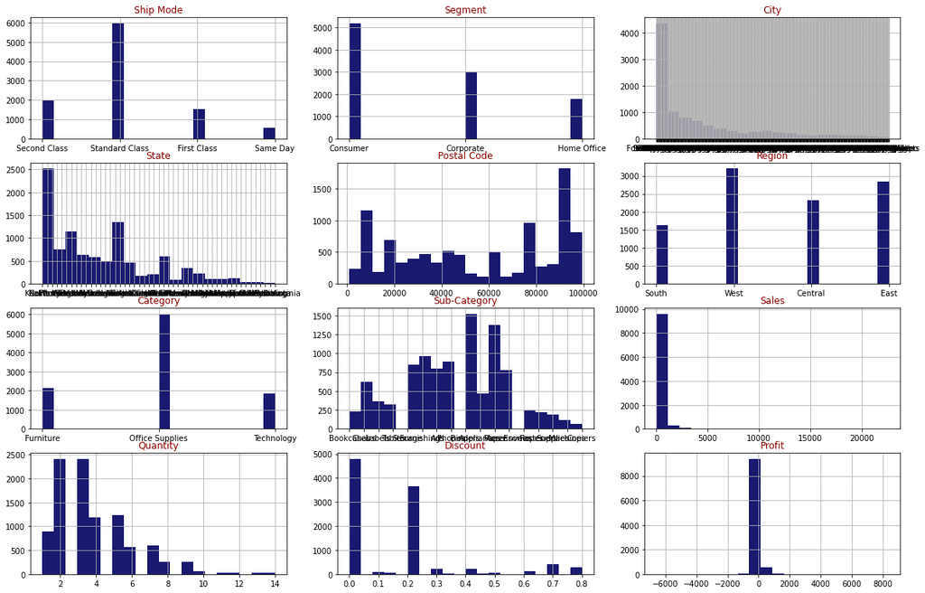

```python
fig=plt.figure(figsize=(20,20))
for i, feature in enumerate(df.columns):
  ax=fig.add_subplot(6,3,i+1)
  df[feature].hist(bins=20,ax=ax,facecolor='midnightblue')
  ax.set_title(feature,color='DarkRed')
```

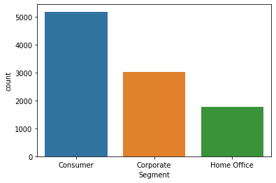

```python
sns.countplot(x=df['Segment'])
```

```
Binders        1523
Paper          1370
Furnishings     957
Phones          889
Storage         846
Art             796
Accessories     775
Chairs          617
Appliances      466
Labels          364
Tables          319
Envelopes       254
Bookcases       228
Fasteners       217
Supplies        190
Machines        115
Copiers          68
Name: Sub-Category, dtype: int64
```

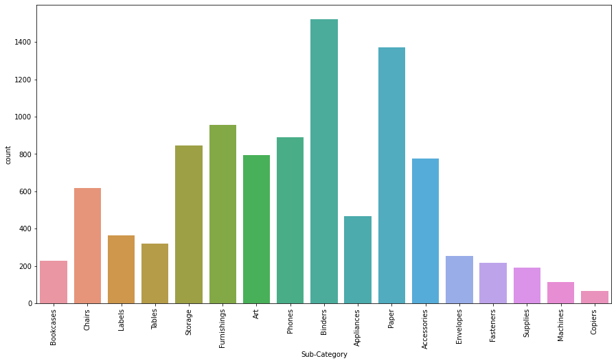

```python
print(df1['Sub-Category'].value_counts())
plt.figure(figsize=(15,8))
sns.countplot(x=df1['Sub-Category'])
plt.xticks(rotation=90)
plt.show()
```

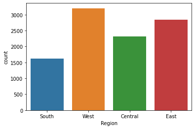

```python
sns.countplot(x=df['Region'])
```

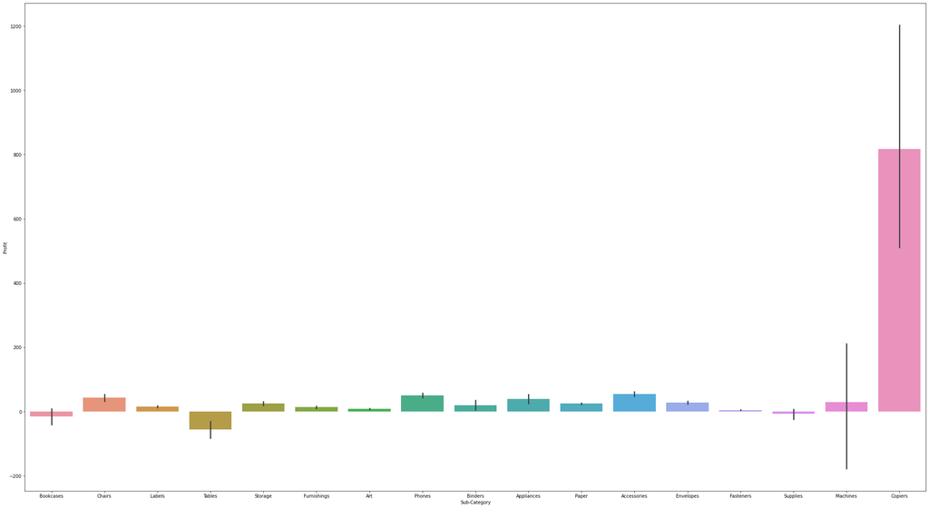

```python
plt.figure(figsize=(36,20))
sns.barplot(x=df['Sub-Category'], y=df['Profit'])
```

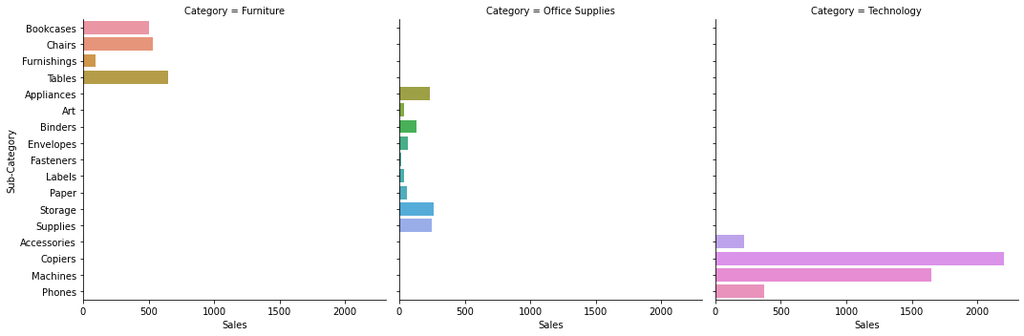

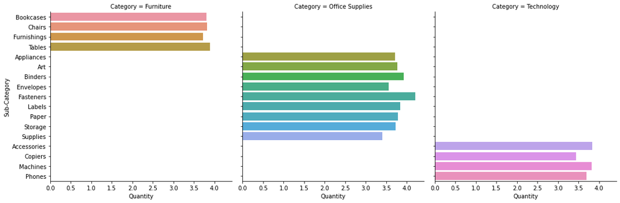

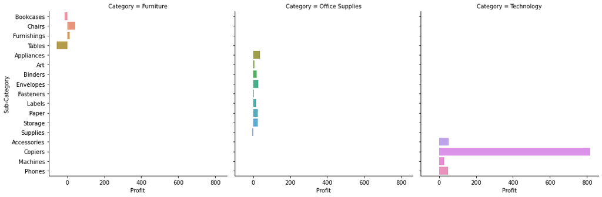

```python
category_group = df.groupby(['Category','Sub-Category'])['Sales','Quantity','Profit'].mean().reset_index()
x = sns.catplot(x="Sales",
                y="Sub-Category",
                col="Category",
                data=category_group,
                kind='bar')

y = sns.catplot(x="Quantity",
                y="Sub-Category",
                col="Category",
                data=category_group,
                kind='bar')

z = sns.catplot(x="Profit",
                y="Sub-Category",
                col="Category",
                data=category_group,
                kind='bar')
```

From these graphs, we can conclude that:-

In technology category, Sales are more than other two category.

Quantity of products are sold almost in equal amount in each category.

In Furniture category, Bookcases and Tables are incurring a lose though Tables are sold most.

In Office Supplies category, there is a very minimal profit in all sub-categories.

In technology category, Copiers provide the most profit among all others.List item

Company must focus in copiers since the sales and profits are heavily influenced by copiers and can discontinue the sales of tables since it is contributing to a heavy loss and steps could be taken to improve profits for other sub categories.

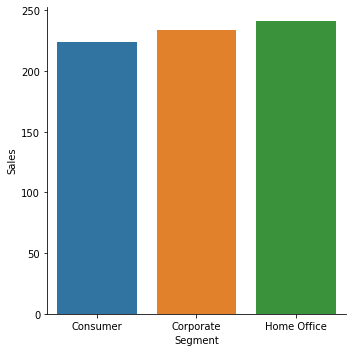

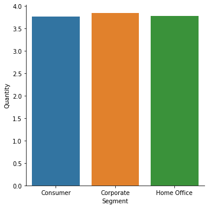

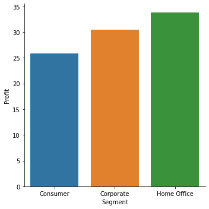

```python
segment_group = df.groupby(['Segment'])['Sales','Quantity','Profit'].mean().reset_index()
x = sns.catplot(x="Segment", y="Sales", data=segment_group, kind='bar')
y = sns.catplot(x="Segment", y="Quantity", data=segment_group, kind='bar')
z = sns.catplot(x="Segment", y="Profit", data=segment_group, kind='bar')
```

From above graphs:-

- All types of Segments have shown almost same number of sales
- All types of Segments have shown almost same number of quantity sold.
- Profit in Consumer Segment is lowest and highest in Home Office

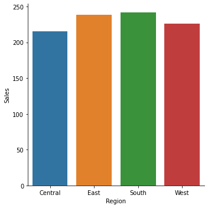

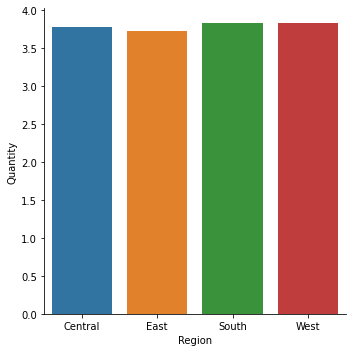

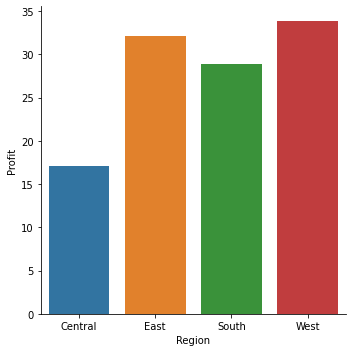

```python
region_group = df.groupby(['Region'])['Sales','Quantity','Profit'].mean().reset_index()
x = sns.catplot(x="Region", y="Sales", data=region_group, kind='bar')
y = sns.catplot(x="Region", y="Quantity", data=region_group, kind='bar')
z = sns.catplot(x="Region", y="Profit", data=region_group, kind='bar')
```

From these graphs, we can conclude that

- Sales are more in Southern and Eastern part of US.
- Quantity of products sold in all the regions are almost same and not much of difference.
- The profits have to be looked at since the West zone is giving almost double the profit as compared to the central one, so the company will have to take steps to analyze the shortcoming in terms of both sales and profits for the central region

```
California              2001
New York                1128
Texas                    985
Pennsylvania             587
Washington               506
Illinois                 492
Ohio                     469
Florida                  383
Michigan                 255
North Carolina           249
Arizona                  224
Virginia                 224
Georgia                  184
Tennessee                183
Colorado                 182
Indiana                  149
Kentucky                 139
Massachusetts            135
New Jersey               130
Oregon                   124
Wisconsin                110
Maryland                 105
Delaware                  96
Minnesota                 89
Connecticut               82
Oklahoma                  66
Missouri                  66
Alabama                   61
Arkansas                  60
Rhode Island              56
Utah                      53
Mississippi               53
Louisiana                 42
South Carolina            42
Nevada                    39
Nebraska                  38
New Mexico                37
Iowa                      30
New Hampshire             27
Kansas                    24
Idaho                     21
Montana                   15
South Dakota              12
Vermont                   11
District of Columbia      10
Maine                      8
North Dakota               7
West Virginia              4
Wyoming                    1
Name: State, dtype: int64
```

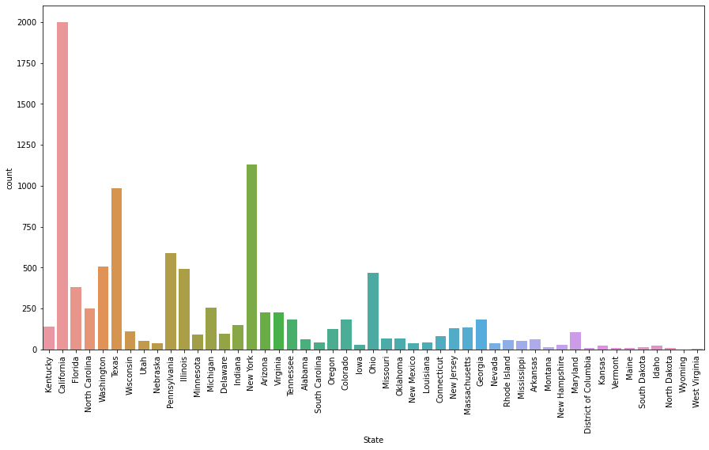

```python
print(df1['State'].value_counts())
plt.figure(figsize=(15,8))
sns.countplot(x=df1['State'])
plt.xticks(rotation=90)
plt.show()
```

```python
f
```

```
Highest 10 Ratios :

                          Sales      Profit  Profit_to_sales
State
District of Columbia   2865.020   1059.5893         0.369837
Delaware              27451.069   9977.3748         0.363460
Minnesota             29863.150  10823.1874         0.362426
Maine                  1270.530    454.4862         0.357714
Arkansas              11678.130   4008.6871         0.343264
Indiana               53555.360  18382.9363         0.343251
Georgia               49095.840  16250.0433         0.330986
Montana                5589.352   1833.3285         0.328004
Rhode Island          22627.956   7285.6293         0.321975
Michigan              76269.614  24463.1876         0.320746
======================================================================
Lowest 10 Ratios:

                      Sales      Profit  Profit_to_sales
State
Florida          89473.7080  -3399.3017        -0.037992
Oregon           17431.1500  -1190.4705        -0.068296
Arizona          35282.0010  -3427.9246        -0.097158
Pennsylvania    116511.9140 -15559.9603        -0.133548
North Carolina   55603.1640  -7490.9122        -0.134721
Texas           170188.0458 -25729.3563        -0.151182
Illinois         80166.1010 -12607.8870        -0.157272
Tennessee        30661.8730  -5341.6936        -0.174213
Colorado         32108.1180  -6527.8579        -0.203309
Ohio             78258.1360 -16971.3766        -0.216864
```

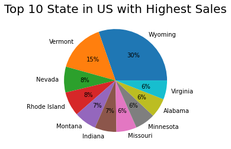

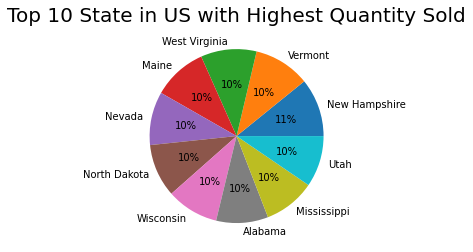

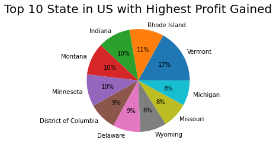

```python
profit_to_sales = pd.DataFrame(df.groupby('State').sum()[['Sales','Profit']])
profit_to_sales['Profit_to_sales'] = profit_to_sales['Profit']/profit_to_sales['Sales']
profit_to_sales.sort_values(by='Profit_to_sales',inplace = True, ascending = False)
print("Highest 10 Ratios :\n")
print(profit_to_sales[:10])
print('='*70)
print("Lowest 10 Ratios:\n")
print(profit_to_sales[-10:])
plt.pie(sales_values, labels=sales_labels, autopct='%1.f%%')
plt.title("Top 10 State in US with Highest Sales", fontsize=20)
plt.show()

plt.pie(quantity_values, labels=quantity_labels, autopct='%1.f%%')
plt.title("Top 10 State in US with Highest Quantity Sold", fontsize=20)
plt.show()

plt.pie(profit_values, labels=profit_labels, autopct='%1.f%%')
plt.title("Top 10 State in US with Highest Profit Gained", fontsize=20)
plt.show()
```

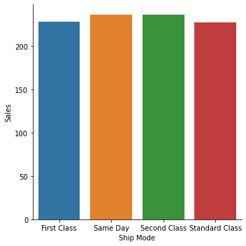

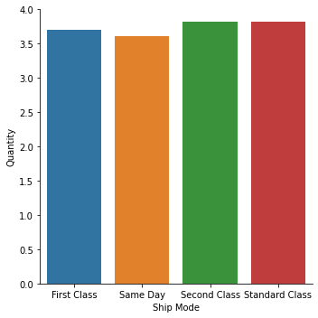

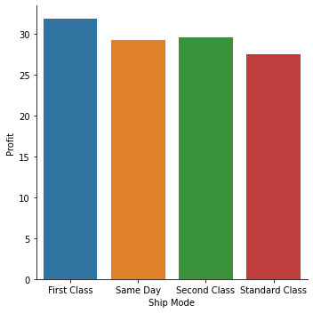

```python
shipmode_group = df.groupby(['Ship Mode'])['Sales','Quantity','Profit'].mean().reset_index()
x = sns.catplot(x="Ship Mode", y="Sales", data=shipmode_group, kind='bar')
y = sns.catplot(x="Ship Mode", y="Quantity", data=shipmode_group, kind='bar')
z = sns.catplot(x="Ship Mode", y="Profit", data=shipmode_group, kind='bar')
```

From these graphs, we can conclude that ship mode doesn't affect the Profit, Sales and Quantity. All types of Ship Mode show the almost same values. Only Standard Class mode gives least profit.

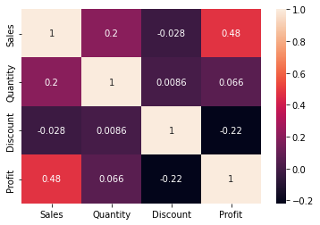

```python
sns.heatmap(df1.corr(),annot=True,data=df1)
```

Here we can show that:

- Discount is negatively correlated with sales and profit
- Also there is good relation between sales and profit which is obvious

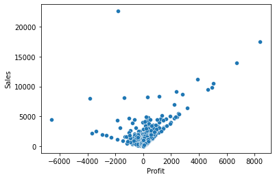

```python
sns.scatterplot(x='Profit',y='Sales',data=df)
```

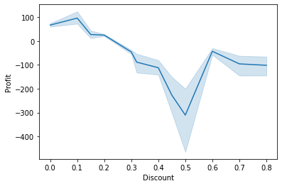

```python
sns.lineplot(x='Discount',y='Profit',data=df)
```

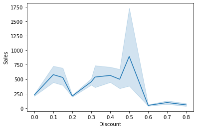

```python
sns.lineplot(x='Discount',y='Sales',data=df)
```

From above two graphs we can conclude that: Sales and Profit share a very assymetric relation under Discount. Under discount when sales is increasing profit decreases.

The company should stop giving high discounts.

```python
pip install nbconvert
```

```python
jupyter nbconvert eda.ipynb
```

[output not shown]